# Step_1_Collection

DG

July 6, 2023

This step is mostly debugging and will not be interesting to anyone who is not analyzing their own data but maybe look at the pretty latter plots. A lot of the debugging is necessary because I added decks in weird ways, Anki is being constantly developed, and I use many addons. If you are running this on your own data you should check the output of each and every code section carefully. Look for label CHANGEME, which for the following notebook is mostly errors.

## LOAD AND CLEAN DATA

Load Anki’s sqlite database and turn it into several R tables.

```r
require(DBI)
#CHANGEME
COLLECTION_PATH <- "collection2025-1-15.anki2"
connection <- dbConnect(RSQLite::SQLite(), dbname=COLLECTION_PATH)
rev <- dbGetQuery(connection,'SELECT * FROM revlog')

#?dbGetQuery
each.table <- dbListTables(connection)
al<-list(each.table)
for (i in each.table) {
  try({
  eh<-dbGetQuery(connection,(paste0('SELECT * FROM ',i)))
  al[[which(each.table==i)]]<-NA
  names(al)[[which(each.table==i)]] <- i
  al[[which(each.table==i)]]<-eh
  })
}
```

```
## Error : no query solution
```

```r
names(al)
```

```
##  [1] "cards"        "col"          "config"       "deck_config"  "decks"
##  [6] "fields"       "graves"       "notes"        "notetypes"    "revlog"
## [11] "sqlite_stat1" "sqlite_stat4" ""             "templates"
```

```r
dbDisconnect(connection)
{
print("following tables did not load properly")
print(each.table[!(each.table %in%  names(al))])
}
```

```
## [1] "following tables did not load properly"
## [1] "tags"
```

```r
note<-al$notes
cards<-al$cards
dek<-al$decks
fields<-al$fields
#names(dek)
#head(dek$id)
notetypes<-al$notetypes
templates<-al$templates
```

```r
#various summaries of a single variable
summ <- function(inc, by=.05){
  try({
  inc<-as.numeric(inc)
    print(str(inc))
    print(summary(inc))
  worth<-table(inc)
  if(length(worth)<10) print(worth)
  hist(inc,breaks=200)
  print(quantile(inc,seq(.000,.999999,length.out=(1/by +2))))
  })
}

#shorter table summary of a single  variable
st <- function(tbl) {
  tbp <- sort(table(tbl),decreasing=T)
  print(tbp[1:min(10,length(tbp))])
}

  milli_to_date <- function(mili) as.Date((mili)/(24*60*60*1000), origin = "1970-01-01")
    milli_to_days <- function(mili) round((mili)/(24*60*60*1000),digits=3)
     secs_to_date <- function(mili) as.Date((mili)/(24*60*60), origin = "1970-01-01")
```

Basic history plots and info. Maybe reveal bug.

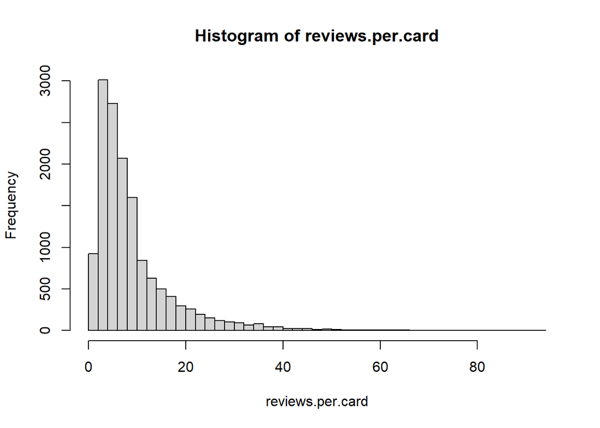

```r
 #milli_to_date <- function(mili) as.Date((mili)/(24*60*60*1000), origin = "1970-01-01")
reviews.per.card <- sort(table(rev$cid),decreasing = T)
hist(reviews.per.card,breaks = 60)
```

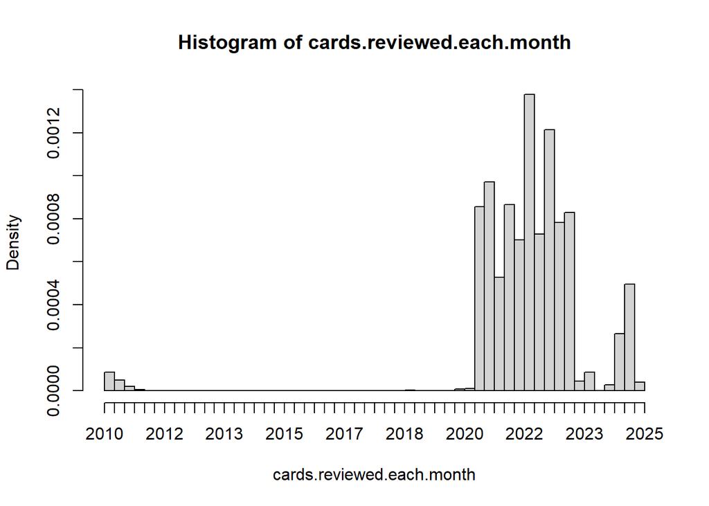

```r
cards.reviewed.each.month <- milli_to_date(rev$id)
hist(cards.reviewed.each.month,breaks = 60)
```

```r
{
print("reviews")
print(length(rev$cid))
print("cards reviewed at least once")
print(length(unique(rev$cid)))
print(paste("when was last review:",milli_to_date(max(rev$id,na.rm=T))))
print(paste("when was first review:",milli_to_date(min(rev$id,na.rm=T))))
}
```

```
## [1] "reviews"
## [1] 136881
## [1] "cards reviewed at least once"
## [1] 14335
## [1] "when was last review: 2025-01-15"
## [1] "when was first review: 2010-09-18"
```

Columns probably for syncing. Removing most. Plot of when cards modified.

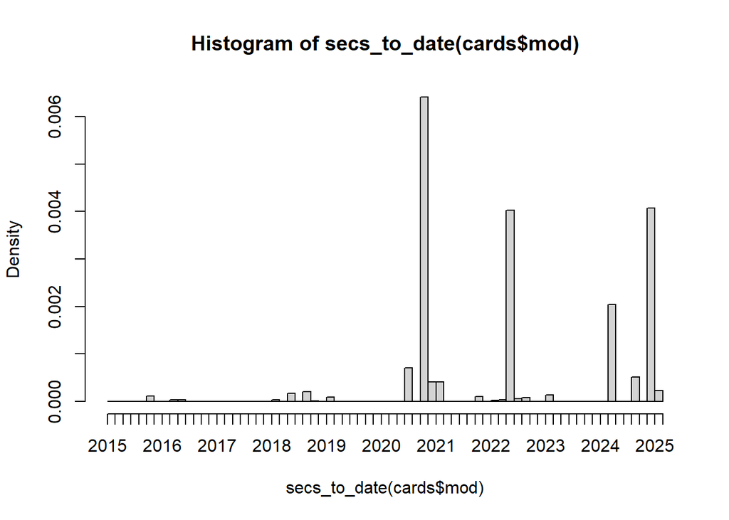

```
## [1] "cards$mod"
## tbl
## 2020-12-18 2022-07-26 2024-11-29 2024-04-02 2024-11-25 2024-09-06 2021-03-01
##      19008      11939       7426       6047       1923       1537       1208
## 2020-08-28 2021-03-28 2018-11-20
##       1172       1030        628
## [1] "note$mod"
## tbl
## 2019-01-21 2016-04-11 2020-09-05 2020-10-06 2018-01-07 2021-05-16 2018-01-01
##       8916       4524       3380       2973       2926       2735       2180
## 2020-10-08 2016-10-23 2021-06-10
##       1992       1232       1203
## [1] "what is mtime_secs?"
## [1] "dek$mtime_secs"
## tbl
## 2021-05-16 2020-10-04 2023-09-10 2020-10-06 2023-12-31 2020-10-08 2021-06-16
##         56         43         36         34         32         31         27
## 2020-12-18 2023-09-13 2023-09-08
##         26         18         17
## [1] "templates$mtime_secs"
## 1970-01-01
##        180
## [1] "notetypes$mtime_secs"
## tbl
## 2023-12-31 2015-12-13 2018-11-20 2020-08-28 2020-09-06 2021-03-21 2022-03-26
##          7          5          5          4          4          4          4
## 2016-05-16 2020-08-27 2013-01-17
##          3          3          2
```

```r
{
hist(secs_to_date(cards$mod),breaks = 100)
print("cards$mod") #actualy keep this for reasons
st(secs_to_date(cards$mod))


#cards$mod <- NULL
names(cards)[names(cards)=="mod"] <- "mod_secs_cards"


print("note$mod")#this not useful; again related to other users?
st(secs_to_date(note$mod))
#hist(secs_to_date(note$mod),breaks = 100)
#note$mod <- NULL
#when last modified double check this is not useful in any way?
note$flds[order(-note$mod)]
names(note)[names(note)=="mod"] <- "mod_note"
note$mod_note <- NULL

print("what is mtime_secs?")
print("dek$mtime_secs") #idk
st(secs_to_date(dek$mtime_secs))
#hist(secs_to_date(dek$mtime_secs),breaks=100)
dek$mtime_secs <- NULL

print("templates$mtime_secs") #idk
st(secs_to_date(templates$mtime_secs))
#hist(secs_to_date(templates$mtime_secs),breaks=100)
templates$mtime_secs <- NULL

print("notetypes$mtime_secs") #idk
st(secs_to_date(notetypes$mtime_secs))
#hist(secs_to_date(notetypes$mtime_secs),breaks = 100)
notetypes$mtime_secs <- NULL
}
```

remove meaningless variables

```r
{


#names(notetypes)[names(notetypes)=="mtime_secs"] <- "mtime_secs_notetypes"


print("cards$data")
st(cards$data)
cards$data<-NULL#unused

print("note$data")
st(note$data)
note$data<- NULL

print("note$flags")
st(note$flags)
note$flags<- NULL#empty

print("note$guid") #globally unique ID
st(note$guid)
note$guid<- NULL #man idk

print("note$id just to check") #globally unique ID
st(note$id)

print("note$csum") #checksum to avoid duplicates but useless for me bc only first 8 chars and there are plenty of cards starting with 'working memory'
#st(note$csum)
# note %>%
#   group_by(csum) %>%
#   mutate(count = n()) %>%
#   ungroup() %>%
#   arrange(sfld)  %>%
#   arrange(-count)
note$csum<- NULL #man idk


}
```

```
## [1] "cards$data"
## tbl
##                                                                {}
##                            36993                             8173
##    {"s":3.71,"d":5.162,"dr":0.9}   {"s":13.82,"d":3.932,"dr":0.9}
##                               96                               44
##    {"s":0.49,"d":7.621,"dr":0.9} {"s":367.92,"d":1.775,"dr":0.93}
##                               30                               17
## {"s":374.11,"d":1.775,"dr":0.93} {"s":386.44,"d":1.775,"dr":0.93}
##                               16                               15
## {"s":380.28,"d":1.775,"dr":0.93} {"s":392.58,"d":1.775,"dr":0.93}
##                               14                               13
## [1] "note$data"
##
## 51324
## [1] "note$flags"
##     0
## 51324
## [1] "note$guid"
## tbl
## -$:Ki/WH6 -%[DlglY6 -&f1#pP8G -@LfARH.6 -{GLT^m`j -|4=^U*#p -1D{p|^ti -5~E$r~)~
##         1         1         1         1         1         1         1         1
## -CS)>j^Uq -H>|cxvON
##         1         1
## [1] "note$id just to check"
## tbl
##  1  2  3  4  5  6  7  8  9 10
##  1  1  1  1  1  1  1  1  1  1
## [1] "note$csum"
```

Its recommended to sync your collection before using this notebook. Remove column used for syncing. USN -1 means needs to be pushed.

```r
{

print("cards$usn")
st(cards$usn)
cards$usn <- NULL#for syncing

print("note$usn")
st(note$usn)
note$usn <- NULL

print("dek$usn")
st(dek$usn)
dek$usn <- NULL

print("notetypes$usn")
st(notetypes$usn)
notetypes$usn <- NULL

print("templates$usn")
st(templates$usn)
templates$usn <- NULL

print("rev$usn")
st(rev$usn)
rev$usn <- NULL
}
```

```
## [1] "cards$usn"
##    -1
## 59347
## [1] "note$usn"
##    -1
## 51324
## [1] "dek$usn"
##  -1
## 503
## [1] "notetypes$usn"
##  -1
## 145
## [1] "templates$usn"
##   0
## 180
## [1] "rev$usn"
##     -1
## 136881
```

rename columns

```r
#this part may better belong in 'merge all' block
names(note)[names(note)=="id"] <- "nid"
names(note)[names(note)=="mid"] <- "ntid"
names(note)[names(note)=="sfld"] <- "cue.text.simple"
names(note)[names(note)=="flds"] <- "card.txt"
names(note)[names(note)=="tags"] <- "tags.note"

names(cards)[names(cards)=="id"] <- "cid"
names(dek)[names(dek)=="id"] <- "did"
names(dek)[names(dek)=="name"] <- "dek.nam"
```

Filtered deck ids replaced with original deck ids. As main meaning of ‘deck’ is similar subject not schedule this is obviously right. Not sure about due though. Better filtered decks not have cards in them when running this notebook i think.

```r
{
 updd <- cards$odid != 0
  print(paste("number cards in filtered decks", sum(updd)))

print("cards$odid")
st((cards$odid))

#cards$odid<-NULL #original deck id before card was moved to filtered deck!!!!!!!
#this is important for deck subject matter so did will be replaced wherever odid is not 0

# cards[updd,]
# todid <- unique(cards$odid[updd])
# tdid <- unique(cards$did[updd])
# summary(cards$did %in% tdid)
# summary(cards$did %in% todid)
# cards[cards$due<0,]
# summary(cards$due)
# summary(cards$odue)

print("cards$odue")
st((cards$odue))
#cards$due get weirds (less than 0) when in filtered deck so due reverted as well
if(sum(updd)>0) {
  #print("never tested TODO WARNING")
  cards$did[updd] <- cards$odid[updd]
  cards$due[updd] <- cards$odue[updd]
}
cards$odid<-NULL
cards$odue<-NULL
}
```

```
## [1] "number cards in filtered decks 0"
## [1] "cards$odid"
##     0
## 59347
## [1] "cards$odue"
## tbl
##     0  1191  1375  1374  1406  1420  1023  1223
## 59331     5     3     2     2     2     1     1
```

Cleaning text function. Clean deck names as well as card text. CHANGEME if bug.

```r
#travels around this notebook because takes so long
{
require(stringr, quietly = T)
clean_strings <- function(ws,remove.digits=T){
ws <- gsub(pattern = '\037'," -- ",ws,fixed = T)
ws <- gsub(pattern = '<img src='," AN_IMAGE_HERE<  ",ws,fixed = T)
ws <- gsub(pattern = '<.+?>'," ",ws,fixed = F)
ws <- gsub(pattern = '[sound:'," SOUND_HERE[",ws,fixed = T)
ws <- gsub(pattern = '\\[.+?\\]'," ",ws,fixed = F)
ws <- gsub(pattern = '{{c'," ",ws,fixed = T)
ws <- gsub(pattern = '::',":",ws,fixed = T)
ws <- gsub(pattern = '}}'," ",ws,fixed = T)
if(remove.digits){
  ws <- gsub(pattern = '[[:digit:]][[:digit:]][[:digit:]]+'," % ",ws,fixed = F)
}
ws <- gsub(pattern = 'nbsp'," ",ws,fixed = T)
ws <- gsub(pattern = '/n'," ",ws,fixed = T)
ws <- str_squish(ws)
ws <- str_squish(ws)
#ws <- str_squish(ws)
#ws <- gsub(pattern = '-- -- ',"-- ",ws,fixed = T)
#ws <- gsub(pattern = '-- -- ',"-- ",ws,fixed = T)
#must not remove fields even if they are not filled
}

if(T){
deck_count <- (unique(dek$dek.nam))

dek$dek.nam.old <- dek$dek.nam
dek$dek.nam <- sapply(dek$dek.nam,clean_strings,remove.digits=F)

deck.names.redun <- length(deck_count) - length(unique(dek$dek.nam))
print(paste0("count of deck names ",deck.names.redun," made identical by string cleaning in dek"))

if(deck.names.redun>0) {
  print("CHANGEME If any deck names became identical to other deck names because of cleaning this will cause errors. Please edit the names of the following decks in anki and run notebook on your new collection file.")
  dek %>%
    group_by(dek.nam) %>%
    summarize(n_dids=length(unique(did))) %>%
    filter(n_dids>1)
  stop()
}
}

if(T){
card_count <- length(unique(note$card.txt))

note$card.txt.old <- note$card.txt
note$card.txt <- sapply(note$card.txt,clean_strings,remove.digits=F)

card.text.redun <- card_count - length(unique(note$card.txt))
print(paste0("count of card.txt ",card.text.redun," made identical by string cleaning in note table"))
if(card.text.redun>0) {
  print("This is not terribly important but consider editing the following cards. Shows the importance of using olds when comparing cards")
  note %>%
    group_by(card.txt) %>%
    summarize(n_old_txt = length(unique(card.txt.old)),
              one.card.txt.old = first(card.txt.old),
              two.card.txt.old = last(card.txt.old)
              ) %>%
    filter(n_old_txt>1) %>%
    arrange(-n_old_txt)

    #note that cards that were duplicates without cleaning will be checked for later
}
}
}
```

```
## [1] "count of deck names 0 made identical by string cleaning in dek"
## [1] "count of card.txt 83 made identical by string cleaning in note table"
## [1] "This is not terribly important but consider editing the following cards. Shows the importance of using olds when comparing cards"
```

```
## # A tibble: 29 × 4
##    card.txt                          n_old_txt one.card.txt.old two.card.txt.old
##    <chr>                                 <int> <chr>            <chr>
##  1 "AN_IMAGE_HERE -- AN_IMAGE_HERE"         47 "<img src=\"151… "<img src=\"152…
##  2 "AN_IMAGE_HERE -- True"                   6 "<img src=\"151… "<img src=\"152…
##  3 "Coefficient of determination: \…         6 "<div>[latex]</… "<div>[latex]</…
##  4 "DT -- -- -- -- --"                       3 "DT[, .(col1, c… "DT[expr1 & exp…
##  5 "Anoxia (reduced oxygen to the b…         2 "Anoxia (reduce… "Anoxia (reduce…
##  6 "Bahrick and Phelps (1987) taugh…         2 "Bahrick and Ph… "Bahrick and Ph…
##  7 "Base rate fallacy -- ignoring a…         2 "<div>Base rate… "Base rate fall…
##  8 "Cycles -- SOUND_HERE -- Present…         2 "Cycles\u001f[s… "Cycles\u001f[s…
##  9 "Driving under many normal weath…         2 "Driving under … "Driving under …
## 10 "Explanations for increased word…         2 "Explanations f… "Explanations f…
## # ℹ 19 more rows
```

## MERGE many different tables into 2

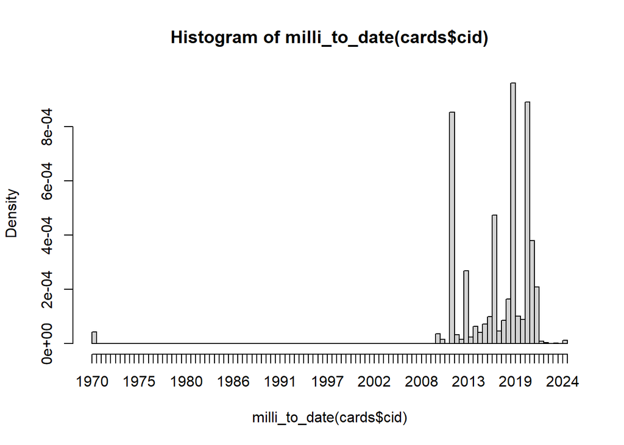

```r
hist(milli_to_date(cards$cid),100)
```

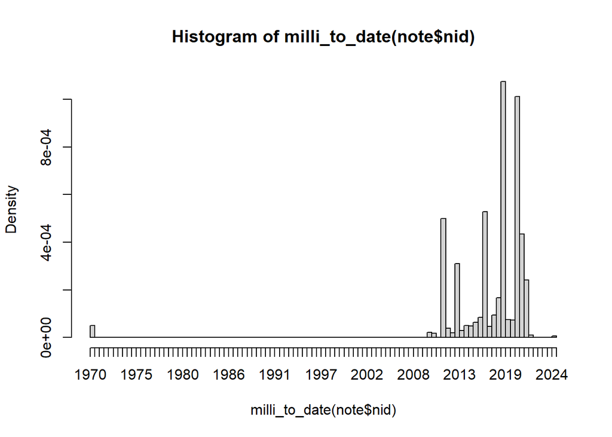

```r
hist(milli_to_date(note$nid),100)
```

All id are the timestamp in miliseconds of objects creation or occurence. Card and note ids are universal based on ankiweb (? i never synced) and so are not meaningful variables. This is good because cid can now be used as purely join key. The two timestamps are very similar. Card is the ‘side’ of a note, ex. one specific empty spot in a cloze deletion phrase. “The number of new cards you have added” in anki’s stats window, uses nid or cid. According to it, I started my collection 12 years ago, which is not even close to true. For determining when something was added to collection I will use DID (deck). When card was reviewed is called id in rev data frame.

Merge all useful info into a single object (sheet). Bug checks too. really two; crd and rev.

```r
{

print(paste("percent card's note id in note's ids:",
            round(sum(cards$nid %in% note$nid)/length(cards$nid),3)))
print(paste("percent note's note id in card's ids:",
            round(sum(note$nid %in% cards$nid)/length(note$nid),3)))
cards<-merge(cards,note,all.x = T,all.y=F)
print(paste("percent card's deck id in deck's ids :",
            round(sum(cards$did %in% dek$did)/length(cards$did),3)))
print(paste("percent deck's deck id in card's ids :",
            round(sum(dek$did %in% cards$did)/length(dek$did),3)))
print("umm decks without cards?? deleted decks?")
crd<-merge(cards,dek[,c("did","dek.nam","dek.nam.old")],all.x = T,all.y=F)

#names(crd)
print(paste("percent review's card id in card's ids :",
            round(sum(rev$cid %in% cards$cid)/length(rev$cid),3)))
print("this is probably percent 1 - percent of cards deleted")
print(paste("percent cards's card id in review's ids :",
            round(sum(cards$cid %in% rev$cid)/length(cards$cid),3)))
print(paste("calculated by ",round(sum(cards$cid %in% rev$cid),3)," / ", round(length(cards$cid),3)))
print("this is just percent of cards ever reviewed and not a bug")

rev2<-merge(rev,crd[,c("cid","did","nid","card.txt","card.txt.old","dek.nam")],all.x = T,all.y=F,by="cid")
}
```

```
## [1] "percent card's note id in note's ids: 1"
## [1] "percent note's note id in card's ids: 1"
## [1] "percent card's deck id in deck's ids : 1"
## [1] "percent deck's deck id in card's ids : 0.845"
## [1] "umm decks without cards?? deleted decks?"
## [1] "percent review's card id in card's ids : 0.999"
## [1] "this is probably percent 1 - percent of cards deleted"
## [1] "percent cards's card id in review's ids : 0.241"
## [1] "calculated by  14296  /  59347"
## [1] "this is just percent of cards ever reviewed and not a bug"
```

```r
stopifnot(
  dim(crd)[1]==dim(cards)[1],
  dim(rev)[1]==dim(rev2)[1])

rev<-rev2
rm(rev2);
#Note to self: some cards are removed later because of terrible deck id.
```

Anki’s own statistics say cards unseen are .244 percent or (56832 - 42990) 13842 / 56832 . It counts notes not cards. See Section TIMESTAMP.

Convert out of int64 because R works more reliably with numeric.

```r
rev <- rev[order(rev$id),]
least_rev_id <- min(rev$id)
rev$idn <- as.numeric(rev$id)

{
print(paste("converted ids same as unconverted:",all(rev$id == rev$idn)))
print(paste("conversion to numeric unsuccesfull:",sum((rev$id - rev$idn) != 0)))
print(paste("when was last review:",milli_to_date(max(rev$idn,na.rm=T))))
}
```

```
## [1] "converted ids same as unconverted: TRUE"
## [1] "conversion to numeric unsuccesfull: 0"
## [1] "when was last review: 2025-01-15"
```

```r
rev$id  <- as.numeric(rev$id)

rev$idn <- NULL
rev$cid <- as.numeric(rev$cid)
rev$did <- as.numeric(rev$did)
rev$nid <- as.numeric(rev$nid)
#summary(rev)
#str(rev)

crd$cid <- as.numeric(crd$cid)
crd$did <- as.numeric(crd$did)
crd$nid <- as.numeric(crd$nid)
crd$ntid <- as.numeric(crd$ntid)
```

## CLEAN more

Later on reps column in crd will not agree with reviews because many reviews will have been deleted for error correction. If u see any deck names just bellow, that means reviews and reps already disagree which is a bug.

```r
crd$in_rev <- (crd$cid) %in% rev$cid
if( !all((crd$reps>0) == crd$in_rev)){
summary(crd$reps>0)
summary(crd$in_rev)

summary(reviews.lost <- (crd$reps>0 & !crd$in_rev))
unique(crd$dek.nam[reviews.lost])
summary(reps.reset <- (!crd$reps & crd$in_rev))
unique(crd$dek.nam[reps.reset])
}
```

Remove rows with nas. In my case these were almost certainly reviews of deleted cards.

```r
{
  #require(naniar)
require(visdat, quietly = T)

rowrm <- apply(rev,1,function(x) any(is.na(x)))

print(paste("number of rows with na which will be removed",sum(rowrm)))
print("this is likely because of missing ids during join")

print(vis_miss(rev[rowrm,], cluster = TRUE))
rev <- rev[!rowrm,]
}
```

```
## [1] "number of rows with na which will be removed 94"
## [1] "this is likely because of missing ids during join"
```

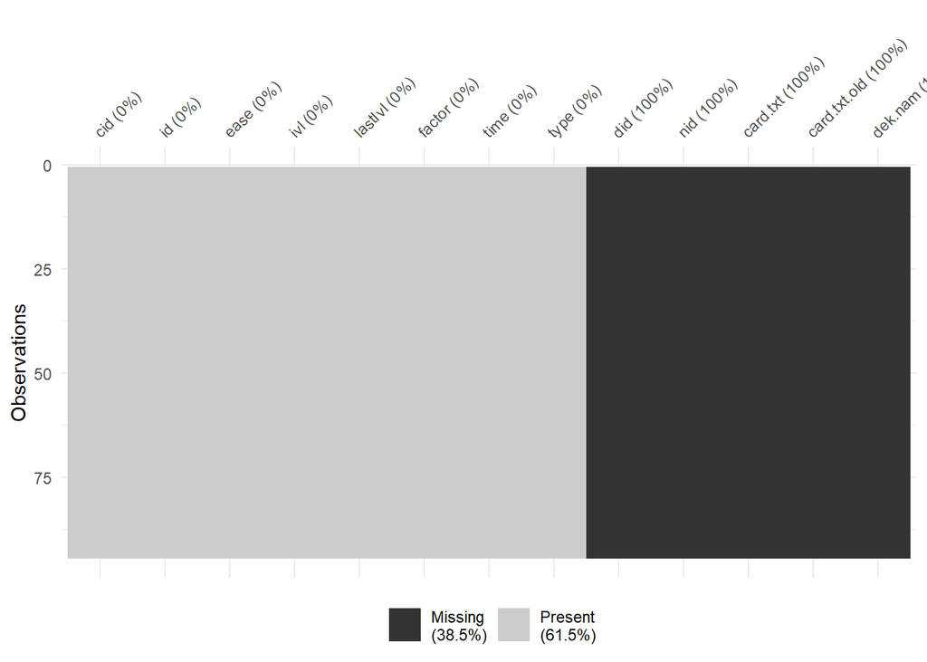

```r
rowrm <- apply(crd,1,function(x) any(is.na(x)))
if(sum(rowrm)>1){
print(paste("Same as above but cards table. number of rows with na which will be removed",sum(rowrm)))
print("this is likely because of missing ids during join")

print(vis_miss(crd[rowrm,], cluster = TRUE))
crd <- crd[!rowrm,]
}
```

Find duplicate card text and card ids from Reviews. Up to user to do something about it. Anki has duplicates finder but its for power users.

```r
#crd <- crd[order(crd$nid),]
#crd$ohno <- duplicated(crd$card.txt.old) + duplicated(crd$card.txt.old, fromLast = TRUE)
#print(crd[crd$ohno>0,])

rev<-rev[order(rev$card.txt.old),]
list.of.rev<-rev %>%
  group_by(card.txt.old) %>%
   summarise(dif.nid=n_distinct(nid),
             deck=first(dek.nam),deck2=last(dek.nam)) %>%
  filter(dif.nid>1)
if(dim(list.of.rev)[1]>0){
print("Duplicate Card Text")
print(unique(c(list.of.rev$deck,list.of.rev$deck2)))
print((list.of.rev[,c(1)]) )
}
```

```
## [1] "Duplicate Card Text"
## [1] "AAA regular -- AAAll the small -- AA selfhelp to S? -- ZAtomic Habits by James Clear -- BAtomic Habits 14"
## # A tibble: 6 × 1
##   card.txt.old
##   <chr>
## 1 "Atomic Why do small habits work?\u001f\u001fHabits are the compound interest…
## 2 "Atomic. Purpose of habits\u001f\u001fThe ultimate purpose of habits is to so…
## 3 "Atomic. when do we find behavior attractive?\u001f\u001fIf a behavior can ge…
## 4 "Four laws of behaviour change\u001f\u001f(1) make it obvious, (2) make it at…
## 5 "Habit\u001f\u001fA habit is a behaviour that has been repeated enough times …
## 6 "When does dopamine spike\u001f\u001fIt is the anticipation of a reward—not t…
```

```r
list.of.rev.idd<-rev %>%
  group_by(nid) %>%
   summarise(dif.nid=n_distinct(card.txt.old),
             deck=first(dek.nam),deck2=last(dek.nam)) %>%
  filter(dif.nid>1)
if(dim(list.of.rev.idd)[1]>0){
print("Multiple IDs per cardtext")
print(unique(c(list.of.rev.idd$deck,list.of.rev.idd$deck2)))
print((list.of.rev.idd[,c(1)]) )
}
```

Duplicates card text with different note ids and in different decks.

```r
dup <- crd %>%
  group_by(card.txt) %>%
  summarize(nid.count=length(unique(nid)),
        did.count=length(unique(did)),
        dek.nam=first(dek.nam),
        deknamtwo=last(dek.nam)) %>%
  filter((nid.count)>1) %>%
  filter((did.count)>1) %>%
  ungroup() %>%
  arrange(dek.nam) %>%
  arrange(-nid.count)


# to.pretty <- sort(table(dup$deck),decreasing=T)
# as.data.frame(list(dek=names(to.pretty),count=to.pretty))
#as_tibble(as.data.frame(sort(table(dup$dek.nam),decreasing=T)))
dup[,c("card.txt","dek.nam","nid.count")]
```

```
## # A tibble: 107 × 3
##    card.txt                                                    dek.nam nid.count
##    <chr>                                                       <chr>       <int>
##  1 AN_IMAGE_HERE -- AN_IMAGE_HERE                              MathAd…        47
##  2 implicit memory -- -- Memories we don't deliberately remem… Psycho…         5
##  3 What is the familiarity trap? -- -- The feeling that you k… AAlear…         3
##  4 Describe an example of dynamic testing. -- -- Dynamic test… ACwass…         3
##  5 Giving new material meaning by expressing it in your own w… ACwass…         3
##  6 It is better to solve a problem than memorize a solution. … ACwass…         3
##  7 Quizzing strengthens learning. (True or False) Explain you… ACwass…         3
##  8 Students do better when given room to struggle with diffic… ACwass…         3
##  9 Taking a few minutes to review what has been learned from … ACwass…         3
## 10 The act of trying to answer a question or attempt to solve… ACwass…         3
## # ℹ 97 more rows
```

Duplicate card text with different note ids but in the same decks.

```r
dup <- crd %>%
  group_by(card.txt) %>%
  summarize(nid.count=length(unique(nid)),
        did.count=length(unique(did)),
        dek.nam=first(dek.nam),
        deknamtwo=last(dek.nam) ) %>%
  filter((nid.count)>1) %>%
  filter((did.count)==1) %>%
  ungroup() %>%
  arrange(dek.nam) %>%
  arrange(-nid.count)

dup[,c("card.txt","dek.nam","nid.count")]
```

```
## # A tibble: 310 × 3
##    card.txt                                                    dek.nam nid.count
##    <chr>                                                       <chr>       <int>
##  1 "Coefficient of determination: \\ --"                       MathAd…         6
##  2 "AN_IMAGE_HERE -- True"                                     MathAd…         6
##  3 "What is a factor? -- -- The term factor refers to a stati… ARlang…         3
##  4 "DT -- -- -- -- --"                                         ARlang…         3
##  5 "¡Cuidado! -- Be careful! -- SOUND_HERE"                    AAA ea…         2
##  6 "Atomic Why do small habits work? -- -- Habits are the com… AAA re…         2
##  7 "Atomic. Purpose of habits -- -- The ultimate purpose of h… AAA re…         2
##  8 "Atomic. when do we find behavior attractive? -- -- If a b… AAA re…         2
##  9 "Four laws of behaviour change -- -- (1) make it obvious, … AAA re…         2
## 10 "Habit -- -- A habit is a behaviour that has been repeated… AAA re…         2
## # ℹ 300 more rows
```

Duplicate decks! if greater than 90% duplicated, recommend deleting one of them anyway. On the other hand making duplicate decks is an quick way to manipulate the Subject detection algorithm.

```r
 crd %>%
  group_by(card.txt.old) %>%
  mutate(nid.count=length(unique(nid)),
        did.count=length(unique(did)) ) %>%
  ungroup() %>%
  group_by(dek.nam) %>%
  summarize(
    percent.elsewhere = (sum(did.count>1) / n())
  ) %>%
  ungroup() %>%
  arrange(-percent.elsewhere)%>%
  filter(percent.elsewhere>.33)
```

```
## # A tibble: 6 × 2
##   dek.nam                                                      percent.elsewhere
##   <chr>                                                                    <dbl>
## 1 AAlearning -- AAAAlearning book make it stick -- makeistick…             0.667
## 2 information retrieval SEO search collab directory -- Chapte…             0.615
## 3 econ market financial literacy -- AP Microeconomics Terms -…             0.417
## 4 AAlearning -- AAAAlearning book make it stick -- Make It St…             0.385
## 5 econ market financial literacy -- AP Microeconomics Terms -…             0.357
## 6 ACwassupposedtostudy -- Make It Stick                                    0.35
```

Quick check.

```r
rev <- rev[order(rev$id),]
{
# print('all id are the timestamp in miliseconds of objects creation or occurence')
 print(paste("when was last review:",milli_to_date(max(rev$id,na.rm=T))))
 print(paste("which rev ids na:",which(is.na(rev$id))))
 print(paste("which rev ids are duplicated:",which(duplicated(rev$id))))
 print(paste("any timings reverse order or lags become zero:",which(diff(rev$id)<=0)))
# print("no more NAs and no more int64s either")
#summary(rev)
#str(rev)
}
```

```
## [1] "when was last review: 2025-01-15"
## [1] "which rev ids na: "
## [1] "which rev ids are duplicated: "
## [1] "any timings reverse order or lags become zero: "
```

Quick check of card table.

```r
{
print("following regards card data table")
print(paste("count of unique card text",length(unique(crd$card.txt.old))))
print(paste("count of unique note ids",length(unique(crd$nid))))
print("difference between the above two values is number of duplicate cards")
print(paste("count of unique card ids",length(unique(crd$cid))))
print(paste("dimensions of card object",paste(dim(crd),collapse = " ")))
}
```

```
## [1] "following regards card data table"
## [1] "count of unique card text 50907"
## [1] "count of unique note ids 51324"
## [1] "difference between the above two values is number of duplicate cards"
## [1] "count of unique card ids 59347"
## [1] "dimensions of card object 59347 22"
```

## TIMESTAMP MISSALIGNMENT

```r
#reviews and cards per deck into Reviews
rev <- rev %>%
  group_by(dek.nam) %>%
   mutate(cards.in.dek=n_distinct(cid),
             revs.in.dek=n())%>%
  arrange(id)%>%
  ungroup()
```

Set to about median ids that are way too early to be timestamps.

```r
{
print(paste0("count of IDs too low to be timestamps in reveiws. rev ", sum(rev$id<10000)," card ", sum(rev$cid<10000), " note ",sum(rev$nid<10000), " deck ", sum(rev$did<10000)))

print(paste0("count of IDs too low to be timestamps in crd. card ", sum(crd$cid<10000), " note ",sum(crd$nid<10000), " deck ", sum(crd$did<10000)))

if(sum(rev$id<10000) > 1) warning("rev id timestamps that are too low removed later")


if(any(crd$did<10000)){
  print(("names of weird decks the Id of which is not timestamp"))
  print((unique(crd$dek.nam[crd$did<10000])))
  print(paste("number of reviews in weird decks",sum(rev$did<10000)))
  print(paste("first,last rev in those decks",
              milli_to_date(rev$id[rev$did<10000][1]),
              milli_to_date(rev$id[rev$did<10000][sum(rev$did<10000)])))
  if(F)#sum(rev$did<10000) < dim(rev)[1]*.005)
    {
  print("looks not too bad in this case so deck will be deleted")
  #print(unique(rev$card.txt.old[rev$did==1]))
  rev<-rev[rev$did>10000,]
  crd<-crd[crd$did>10000,]
  }
  else{
    print("deck id stamp will be set near to median")
    medek <- median(sort((crd$did))) - 300000000
    while(any(crd$did<10000)){
    while((medek %in% crd$did) ||
          (medek %in% crd$nid) ||
          (medek %in% rev$id) ||
          (medek %in% crd$cid)) {
      medek<-medek-1
    }
    rev$did[rev$did==min(crd$did)]<-medek
    crd$did[crd$did==min(crd$did)]<-medek
    }
  }
}
}
```

```
## [1] "count of IDs too low to be timestamps in reveiws. rev 0 card 0 note 0 deck 114"
## [1] "count of IDs too low to be timestamps in crd. card 520 note 520 deck 23"
## [1] "names of weird decks the Id of which is not timestamp"
## [1] "information retrieval SEO search collab directory -- GGL shortcuts"
## [1] "number of reviews in weird decks 114"
## [1] "first,last rev in those decks 2020-07-26 2020-09-17"
## [1] "deck id stamp will be set near to median"
```

```r
if(any(crd$nid<10000)){
  print(("names of weird decks the nId of which is not timestamp"))
  print((unique(crd$dek.nam[crd$nid<10000])))
  print(paste("number of reviews of weird notes",sum(rev$nid<10000)))
  print(paste("first,last rev of those notes",
              milli_to_date(rev$id[rev$nid<10000][1]),
              milli_to_date(rev$id[rev$nid<10000][sum(rev$nid<10000)])))
  if(F)#sum(rev$nid<10000) < dim(rev)[1]*.005)
    {
  print("looks not too bad in this case so notes will be deleted")
  #print(unique(rev$card.txt.old[rev$nid==1]))
  rev<-rev[rev$nid>10000,]
  crd<-crd[crd$nid>10000,]
  }
  else{
    print("note id stamp will be set near to median")
    medek <- median(sort((crd$nid)))
    while(any(crd$nid<10000)){
    while((medek %in% crd$did) ||
          (medek %in% crd$nid) ||
          (medek %in% rev$id) ||
          (medek %in% crd$cid)) {
      medek<-medek+1
    }
    rev$nid[rev$nid==min(crd$nid)]<-medek
    crd$nid[crd$nid==min(crd$nid)]<-medek
    }
  }
}
```

```
## [1] "names of weird decks the nId of which is not timestamp"
## [1] "AAtechComplexBad -- Tech Terms"
## [1] "number of reviews of weird notes 0"
## [1] "first,last rev of those notes NA "
## [1] "note id stamp will be set near to median"
```

```r
if(any(crd$cid<10000)){
  print(("names of weird decks the cid of which is not timestamp"))
  print((unique(crd$dek.nam[crd$cid<10000])))
  print(paste("number of reviews of weird cards",sum(rev$cid<10000)))
  print(paste("first,last rev of those cards",
              milli_to_date(rev$id[rev$cid<10000][1]),
              milli_to_date(rev$id[rev$cid<10000][sum(rev$cid<10000)])))
  if(F)#sum(rev$nid<10000) < dim(rev)[1]*.005)
    {
  print("looks not too bad in this case so notes will be deleted")
  #print(unique(rev$card.txt.old[rev$nid==1]))
  rev<-rev[rev$cid>10000,]
  crd<-crd[crd$cid>10000,]
  }
  else{
    print("card id stamp will be set near to median")
    medek <- median(sort((crd$cid)))
    while(any(crd$cid<10000)){
    while((medek %in% crd$did) ||
          (medek %in% crd$nid) ||
          (medek %in% rev$id) ||
          (medek %in% crd$cid)) {
      medek<-medek+1
    }
    rev$cid[rev$cid==min(crd$cid)]<-medek
    crd$cid[crd$cid==min(crd$cid)]<-medek
    }
  }
}
```

```
## [1] "names of weird decks the cid of which is not timestamp"
## [1] "AAtechComplexBad -- Tech Terms"
## [1] "number of reviews of weird cards 0"
## [1] "first,last rev of those cards NA "
## [1] "card id stamp will be set near to median"
```

```r
{
  print(paste0("count of IDs too low to be timestamps in reveiws. rev ", sum(rev$id<10000)," card ", sum(rev$cid<10000), " note ",sum(rev$nid<10000), " deck ", sum(rev$did<10000)))

print(paste0("count of IDs too low to be timestamps in crd. card ", sum(crd$cid<10000), " note ",sum(crd$nid<10000), " deck ", sum(crd$did<10000)))


print(paste("total revs left:",dim(rev)[1]))
if(sum(rev$cid>rev$id)>0) print(paste("number reviews with card created after review somehow ",sum(rev$cid>rev$id)))
#if(sum(rev$did>(rev$cid))>0) print(paste("number reviews with deck created after card somehow",sum(rev$did>(rev$cid-10))))
#as established cid is not relevant

rev$time.missalign=rev$did>rev$id
if(sum(rev$time.missalign)>0) print(paste("number reviews with deck created after review somehow",sum(rev$time.missalign)))
}
```

```
## [1] "count of IDs too low to be timestamps in reveiws. rev 0 card 0 note 0 deck 0"
## [1] "count of IDs too low to be timestamps in crd. card 0 note 0 deck 0"
## [1] "total revs left: 136787"
## [1] "number reviews with deck created after review somehow 2473"
```

In my database most reviews before deck creation were caused by an Anki upgrade changed them. TODO (likely problematic) They should be fixed by undoing the change but currently just deleted. Also some of the decks were installed in a weird way and kept the makers review history. These reviews will be deleted. One case was probably caused by editing a card and should be ignored. Could moving cards between decks cause this problem too?

Following code removes reviews made before the deck timestamp and reviews made before a certain date. Deck ids will be increased.

CHANGEME U may want to change which of the 4 removal methods activate by altering the Ts and Fs. Remove specific decks. Remove reviews before their deck’s timestamp. Remove reviews before a certain time set in ‘first_time_used_anki’. Change deck id to after anki is used first time.

```r
{
#remove some specific decks
if(F){
library(stringr)
rev<-rev[!str_detect(rev$dek.nam,
              stringr::fixed("ProgramingAdvancedWide")),]
rev<-rev[!str_detect(rev$dek.nam,
              stringr::fixed("Paper Recursive Feedback")),]

crd<-crd[!str_detect(crd$dek.nam,
              stringr::fixed("ProgramingAdvancedWide")),]

rev %>%
  arrange(id) %>%
  group_by(dek.nam) %>%
  arrange(id) %>%
   summarise(cards.in.dek=n_distinct(cid),
             revs.in.dek=n())%>%
  arrange(desc(cards.in.dek))
}
#remove reviews before their decks
if(T){
  rev$time.missalign=rev$did>rev$id
  print(" ")
print(paste("number reviews with deck created after review to be deleted", sum(rev$time.missalign)))
print(as_tibble(as.data.frame(table(rev[rev$time.missalign,]$dek.nam))))
  rev <- rev[!rev$time.missalign,]
}
#remove reviews before a certain time
if(T){
  first_time_used_anki <- 1.548563e+12
  to_fix <- rev$id<first_time_used_anki
  print(paste("number reviews before ",milli_to_date(first_time_used_anki)," to be deleted ",  sum(to_fix)))
  print(as_tibble(as.data.frame(table(rev[to_fix,]$dek.nam))))
rev <- rev[!to_fix,]
}

#move deck id to better a point in time
if(T){
  deks_to_fix <- unique(crd[crd$did<first_time_used_anki,]$dek.nam)
  print(" ")
  print("deck id timestamps updated to about anki first use ")
  print(deks_to_fix[1:5])
  #real_first_use <- (min(rev$id))
  subtract_mseconds <- 0
  for(i in deks_to_fix){
    subtract_mseconds <- subtract_mseconds + 60000
    while((subtract_mseconds %in% rev$did) ||
     (subtract_mseconds %in% rev$id) ||
     (subtract_mseconds %in% rev$cid)) subtract_mseconds<-subtract_mseconds+1
    rev[rev$dek.nam==i,]$did <- first_time_used_anki - subtract_mseconds
    crd[crd$dek.nam==i,]$did <- first_time_used_anki - subtract_mseconds
  }
}
}
```

```
## [1] " "
## [1] "number reviews with deck created after review to be deleted 2473"
## # A tibble: 4 × 2
##   Var1                                                                      Freq
##   <fct>                                                                    <int>
## 1 AAA regular -- AAAll the small -- AA selfhelp to S? -- own                   8
## 2 AAlearning -- learning theory of knowledge -- 20 Rules of Formatting Kn…  2213
## 3 Alogic reasoning epistemology explain -- alearning Rationality -- Paper…   138
## 4 information retrieval SEO search collab directory -- GGL shortcuts         114
## [1] "number reviews before  2019-01-27  to be deleted  46"
## # A tibble: 2 × 2
##   Var1                                                                      Freq
##   <fct>                                                                    <int>
## 1 AStatsBasic -- DSRI Unit 6: Intro to Linear Regression                      44
## 2 MathAdvanced -- Advanced Statistics -- Lectures -- Combined -- Lecture …     2
## [1] " "
## [1] "deck id timestamps updated to about anki first use "
## [1] "MathAdvanced -- Advanced Statistics -- Lectures -- Combined -- Lecture 1a Review of uni- andbivariate statistics"
## [2] "MathAdvanced -- Advanced Statistics -- Lectures -- Combined -- Lecture 1b Missing Data"
## [3] "MathAdvanced -- Advanced Statistics -- Lectures -- Combined -- Lecture 2a ANCOVA"
## [4] "MathAdvanced -- Advanced Statistics -- Lectures -- Combined -- Lecture 3a MANOVA – part 2"
## [5] "MathAdvanced -- Advanced Statistics -- Summary -- Combined -- Introduction (T&F, C1&C2, Lecture1)"
```

```r
crd$in_rev <- (crd$cid) %in% rev$cid
```

Review id timestamps after trimming

```r
{
rev <- rev[order(rev$id),]
print(paste("when was first review:",milli_to_date(min(rev$id,na.rm=T))))
print(paste("when was last review:",milli_to_date(max(rev$id,na.rm=T))))
print(paste("which rev ids na:",which(is.na(rev$id))))
print(paste("which rev ids are duplicated:",which(duplicated(rev$id))))
print(paste("dimensions of review and card decks ", paste(c(dim(rev),dim(crd)),collapse = " ")))
print(paste("different cards ever reviewd", length(unique(rev$cid))))
print(paste("different notes ever reviewd", length(unique(rev$nid))))

}
```

```
## [1] "when was first review: 2020-08-27"
## [1] "when was last review: 2025-01-15"
## [1] "which rev ids na: "
## [1] "which rev ids are duplicated: "
## [1] "dimensions of review and card decks  134268 16 59347 22"
## [1] "different cards ever reviewd 14244"
## [1] "different notes ever reviewd 9188"
```

```r
#Review table grouped by card.txt.old. End user need not bother with it.
if(F){
revie.deck.mis <- rev %>%
  group_by(card.txt.old) %>%
   summarise(deck.name = first(dek.nam),
             revs.before.deck = sum(did>id),
             revstotal = n(),
             first.rview = first(id),
             deck.date = first(did)) %>%
  group_by(deck.name) %>%
   summarise(cardstotal=n(),
            cards.ever.before.deck = sum(revs.before.deck > 1),
            revs.total = sum(revstotal),
            revs.before.deck= sum(revs.before.deck),
             first.review=milli_to_date(first(first.rview)),
             deck.date=milli_to_date(first(deck.date))) %>%
  mutate(percent.new=revs.before.deck / revs.total)

print(revie.deck.mis[order(revie.deck.mis$first.review),])
#summary(rev)
#str(rev)
}
```

## HEIRARCHY AND ACCUMULATION OF COLLECTION

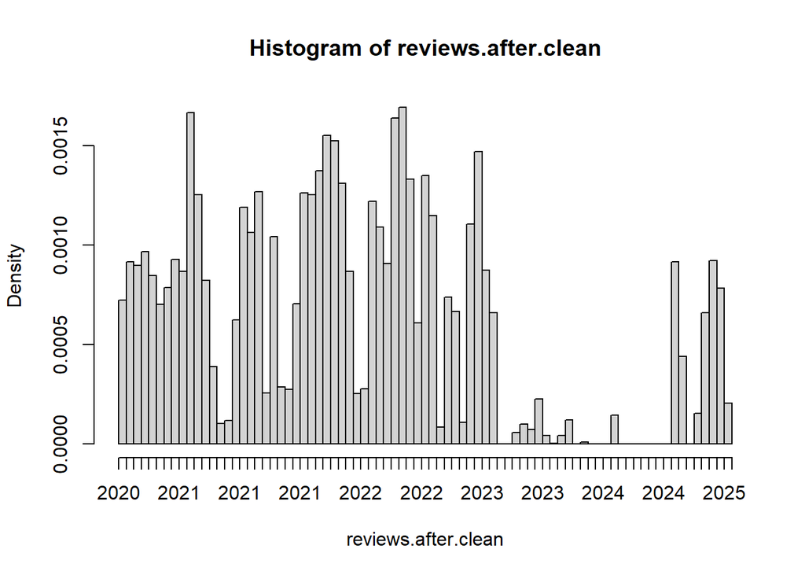

```
## [1] "percent notes actualy ever tried 0.241"
## [1] "calculated as  14277 / 59347"
## [1] "looks like user has been making too many plans"
## [1] "number of reviews before notes 0"
```

```r
{
reviews.after.clean <- milli_to_date(rev$id)
hist(reviews.after.clean, breaks = 60)
# cards$created_date <- as.yearmon(anydate((cards$cid)/1000))
# cards_summary <- sqldf("select created_date, count(*) as n_cards from cards group by created_date order by created_date")
percent_unseen <- round(digits=3,sum((crd$nid) %in% rev$nid)/length((crd$nid)))
print(paste("percent notes actualy ever tried",percent_unseen
))
print(paste("calculated as ",
            sum((crd$nid) %in% rev$nid),
                                 '/',length((crd$nid))
))
if(percent_unseen<.5) print("looks like user has been making too many plans")

if(T){
rev <- rev[order(rev$id),]
rev$first.rev.of.a.note<-(!duplicated(rev$nid))

reved <- rev %>%
  group_by(nid) %>%
  summarise(min=min(id)) %>%
  arrange(min) %>% ungroup()
print(paste("number of reviews before notes", sum(reved$nid >= reved$min)))

#print(paste("both calculation methods agree",length(reved$min)==length(rev$id[rev$first.rev.of.a.note])))
}
}
```

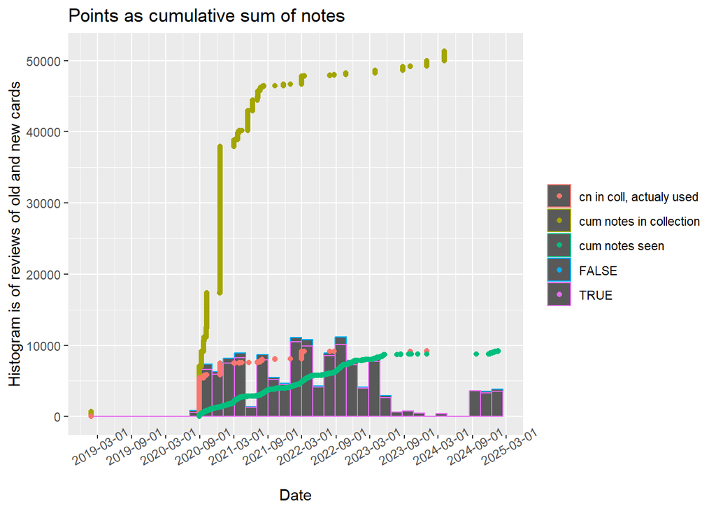

```r
rev<-rev[order(rev$id),]
crd<-crd[order(crd$did),]

nts_fg <- crd$did[!duplicated(crd$nid)]
nts_gd <- (crd$did[!duplicated(crd$nid) & (crd$in_rev)])

ggplot()+
  geom_histogram(aes(x=milli_to_date(rev$id),color=!rev$first.rev.of.a.note),binwidth = 60)+
  geom_point(aes(x=milli_to_date(nts_fg),cumsum(rep(1,times=length(nts_fg))),
                 color="cum notes in collection"))+
  geom_point(aes(x=milli_to_date(nts_gd),cumsum(rep(1,times=length(nts_gd))),
                 color="cn in coll, actualy used"))+
  geom_point(aes(x=milli_to_date(rev$id[rev$first.rev.of.a.note]),
                 cumsum(rep(1,times=length(rev$id[rev$first.rev.of.a.note]))),
                 color="cum notes seen"))+
  xlab("Date") + ylab("Histogram is of reviews of old and new cards")+
  ggtitle( "Points as cumulative sum of notes")+
  scale_x_date(date_breaks="6 months")+
  theme( axis.text.x = element_text(angle=30) )+
  labs(colour = " ")
```

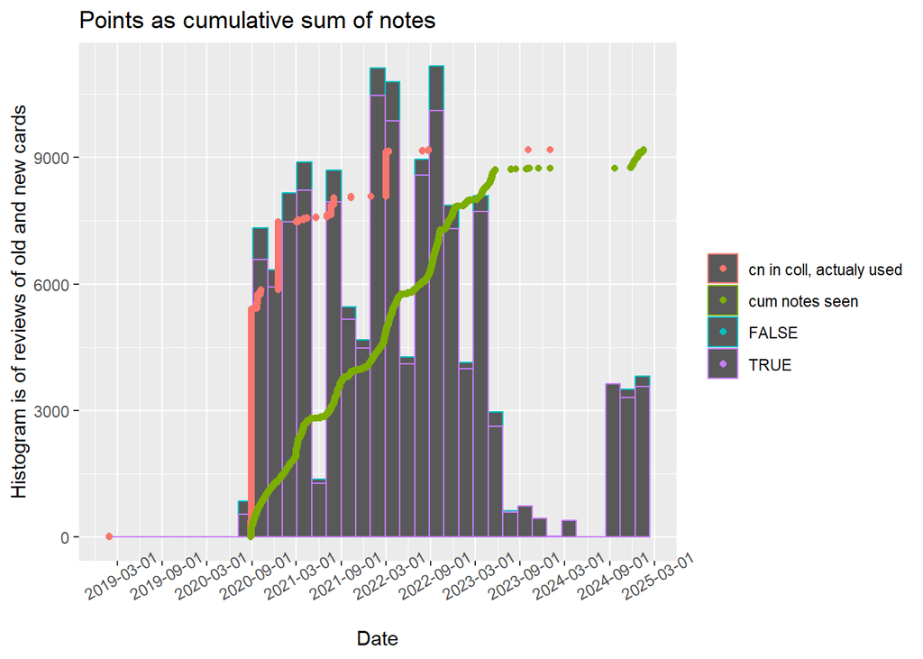

```r
ggplot()+
  geom_histogram(aes(x=milli_to_date(rev$id),color=!rev$first.rev.of.a.note),binwidth = 60)+
  geom_point(aes(x=milli_to_date(nts_gd),cumsum(rep(1,times=length(nts_gd))),
                 color="cn in coll, actualy used"))+
  geom_point(aes(x=milli_to_date(rev$id[rev$first.rev.of.a.note]),
                 cumsum(rep(1,times=length(rev$id[rev$first.rev.of.a.note]))),
                 color="cum notes seen"))+
  xlab("Date") + ylab("Histogram is of reviews of old and new cards")+
  ggtitle( "Points as cumulative sum of notes")+
  scale_x_date(date_breaks="6 months")+
  theme( axis.text.x = element_text(angle=30) )+
  labs(colour = " ")
```

The TRUE is reviews of cards already reviewed and FALSE is reviews of new notes. A two sided note will make 2 cards like hand -> mano and mano -> hand. Anki already has similar plot.

When were cards added that have ever been reviewed? Good and bad decisions? INTERESTING

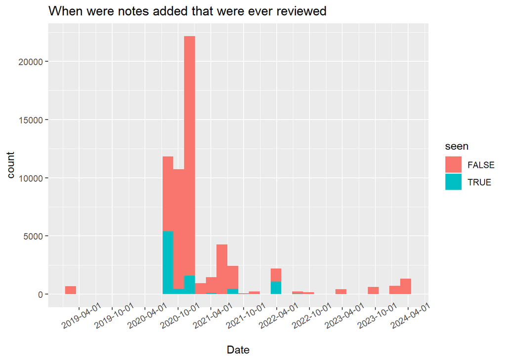

```r
qdf <- data.frame(dion = c(nts_fg, nts_gd),
                  seen=c(rep(F,times=length(nts_fg)),rep(T,times=length(nts_gd))))

ggplot(data=qdf)+
  geom_histogram(aes(x=milli_to_date(dion),fill= seen),binwidth = 60)+
  scale_x_date(date_breaks="6 months")+
  theme( axis.text.x = element_text(angle=30) )+
  xlab("Date")+
  ggtitle( "When were notes added that were ever reviewed")
```

SELF REVIEW In first 2 months additions were well considered enough but then got obsessed with additions. Somewhere around 2021-10 this stopped and additions became better planned again.

```r
crd$simplest.name <- apply(crd, 1, function(x){
  levs<-str_split(x[names(x)=="dek.nam"],stringr::fixed(" -- "))[[1]]
  return(levs[length(levs)])
} )


rev$simplest.name <- apply(rev, 1, function(x){
  levs<-str_split(x[names(x)=="dek.nam"],stringr::fixed(" -- "))[[1]]
  return(levs[length(levs)])
} )

opp <- crd %>%
  group_by(simplest.name) %>%
  summarise(Cards_in_deck = n())

#stopifnot("final names of decks in reviews not in deck data.frame" = all(rev$simplest.name %in% opp$simplest.name))

any.odd.changes <- dim(rev)

rev <- merge(rev,opp,all.x = T,all.y=F , by ="simplest.name")

stopifnot("number rows changed after merge" = dim(rev)[1]==any.odd.changes[1],
  "number columns changed after merge" = (dim(rev)[2])==(any.odd.changes[2]+1))
```

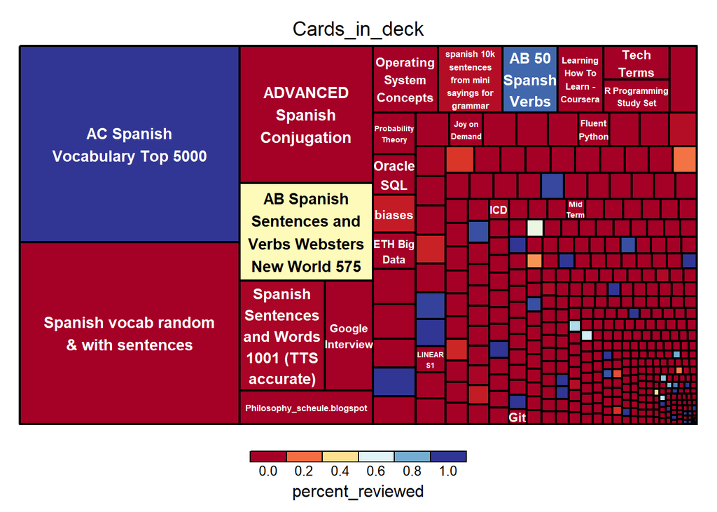

```r
#require(treemapify)
require(treemap, quietly = T)
require(grDevices, quietly = T)

opp <- crd %>%
  group_by(simplest.name) %>%
  summarise(
            Cards_in_deck = n(),
            did = first(did),
            seen.once = sum((cid) %in% rev$cid)
  ) %>%
  mutate(
    percent_reviewed = (seen.once / Cards_in_deck),
    Sqrt.cards.in.deck = sqrt(Cards_in_deck),
    sqrt.cards.seen.once = sqrt(seen.once)
  )

#dim(opp)
#summary(opp)

treemap(opp, index="simplest.name", vSize="Cards_in_deck", vColor="percent_reviewed", type="manual", palette="RdYlBu")
```

```r
 # itreemap(opp)

  treemap(opp, index="simplest.name", vSize="sqrt.cards.seen.once", vColor="percent_reviewed", type="manual", palette="RdYlBu")
```

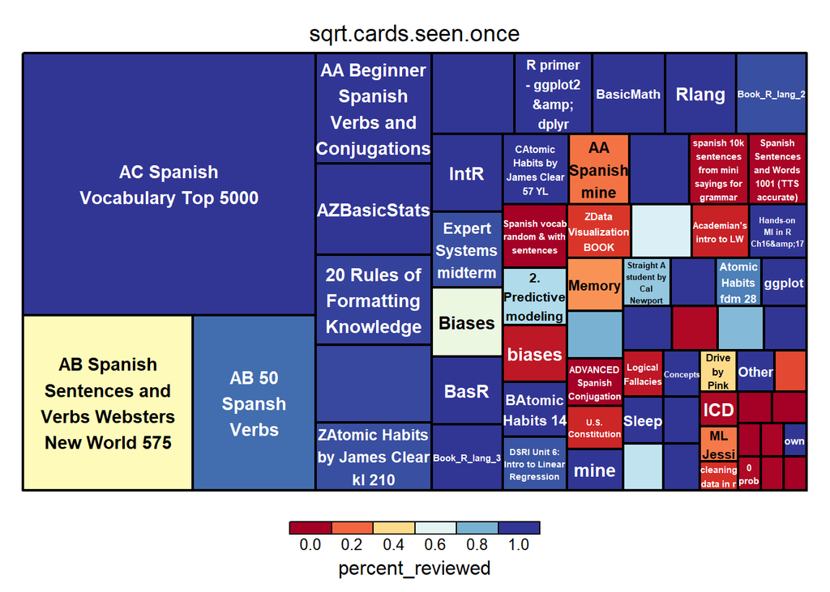

TODO animate over time events of great addition?

Separate folder path into each folder name. First rev then crd. Check if one folder name appears in another hierarchy level. Up to user to fix.

```r
dek_name_to_heir <- function(var.to.split){
split_str <- str_split(var.to.split,stringr::fixed(" -- "))
pre_padded_df <- sapply(split_str, simplify="matrix",function(x){
  for(i in 1:(20-length(x))) x<-c(x,"")
return(x)
})
dek_heir_padded <- as.data.frame(t(pre_padded_df))
levels_not_empty <- (apply(dek_heir_padded, 2,
                           function(x) length(unique(x)))!=1)
dek_heir_padded <- dek_heir_padded[,levels_not_empty]
max_lv <<- dim(dek_heir_padded)[2]
for(i in (max_lv):1) names(dek_heir_padded)[i] <- paste0("dek.heir.lev.",i)
return(dek_heir_padded)
}
dek_heir_unfurled <- dek_name_to_heir(rev$dek.nam)
#print(dek_heir_unfurled)
rev <- cbind(rev,dek_heir_unfurled)

for(itr in 1:(max_lv-1)){#itr<-1
  for(i in (max_lv-itr):1){#i<-1
    wish <- (unique(rev[,paste0("dek.heir.lev.",i)]) %in%                 unique(rev[,paste0("dek.heir.lev.",i+itr)]))
  #print(wish)
    itsy<-unique(rev[,paste0("dek.heir.lev.",i)])[wish]
    if(length(itsy)>0) if(any(nchar(itsy)>0)) print(paste("duplicate deck names ",itsy))
  }}

dek_heir_unfurled <- dek_name_to_heir(crd$dek.nam)
print(head(dek_heir_unfurled))
```

```
##   dek.heir.lev.1                          dek.heir.lev.2 dek.heir.lev.3
## 1    AStatsBasic DSRI Unit 6: Intro to Linear Regression
## 2    AStatsBasic DSRI Unit 6: Intro to Linear Regression
## 3    AStatsBasic DSRI Unit 6: Intro to Linear Regression
## 4    AStatsBasic DSRI Unit 6: Intro to Linear Regression
## 5    AStatsBasic DSRI Unit 6: Intro to Linear Regression
## 6    AStatsBasic DSRI Unit 6: Intro to Linear Regression
##   dek.heir.lev.4 dek.heir.lev.5 dek.heir.lev.6
## 1
## 2
## 3
## 4
## 5
## 6
```

```r
print(tail(dek_heir_unfurled))
```

```
##       dek.heir.lev.1 dek.heir.lev.2 dek.heir.lev.3 dek.heir.lev.4
## 59342          zzfun          Quote   PublicQuotes
## 59343          zzfun          Quote   PublicQuotes
## 59344          zzfun          Quote   PublicQuotes
## 59345          zzfun          Quote   PublicQuotes
## 59346          zzfun          Quote   PublicQuotes
## 59347          zzfun          Quote   PublicQuotes
##       dek.heir.lev.5 dek.heir.lev.6
## 59342
## 59343
## 59344
## 59345
## 59346
## 59347
```

```r
crd <- cbind(crd,dek_heir_unfurled)
```

```r
for(itr in 1:(max_lv-1)){#itr<-1
  for(i in (max_lv-itr):1){#i<-1
    wish <- (unique(crd[,paste0("dek.heir.lev.",i)]) %in%                 unique(crd[,paste0("dek.heir.lev.",i+itr)]))
  #print(wish)
    itsy<-unique(crd[,paste0("dek.heir.lev.",i)])[wish]
    if(length(itsy)>0) {
      if(any(nchar(itsy)>0)){
      print(print(paste("duplicate deck names ",itsy)))
    }}
  }}
```

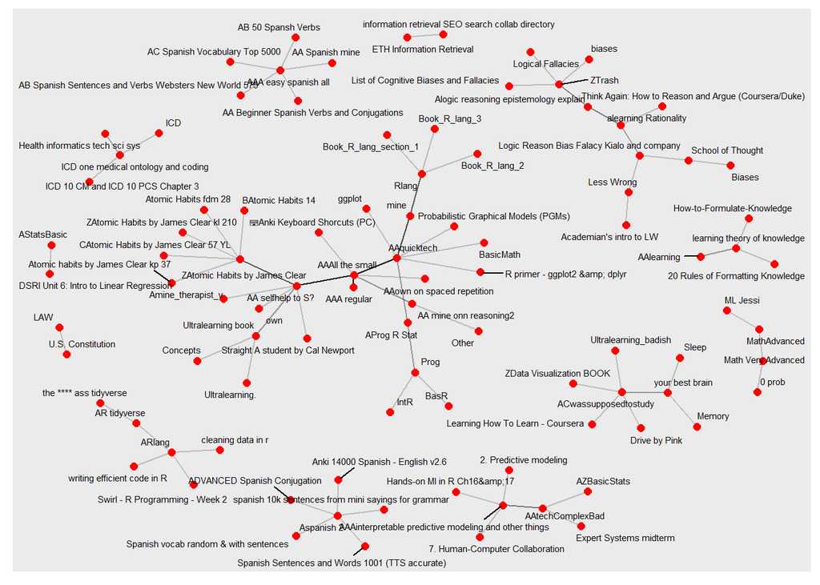

```r
{
dx <- c("dek.heir.lev.1"  ,
 "dek.heir.lev.2"   ,   "dek.heir.lev.3" ,
 "dek.heir.lev.4"   ,   "dek.heir.lev.5" ,    "dek.heir.lev.6")
revgrp <- rev[,c(dx)]
#names(rev)
revgrp <- revgrp[!duplicated(revgrp),]
lvone <- unique(revgrp[,(1)])
edges <- data.frame(from=rep("root",length(lvone)),to=lvone)
edges <- data.frame(from=c(),to=c())
for(i in 2:dim(revgrp)[2]){ #i<-2
  hold <- data.frame(from= revgrp[,(i-1)], to= revgrp[,(i)])
  edges <- rbind(edges,hold)
}

set.seed(1234)
#names(edges)
edges <- edges[edges$to!="",]
nodes <- data.frame(node_key =unique(unlist(edges)))
g <- tbl_graph(edges=edges, directed=TRUE, nodes=nodes)
yout <- create_layout(g, layout = 'igraph', algorithm = 'fr' )
ggraph(g,layout=yout) +
  geom_edge_link(alpha=.2) +
  geom_node_point(size=2,color="red") +
  geom_node_text(aes(label = node_key),
                 repel=T,size=2)#angle=10,

#require(reactable)
#?reactable
}
```

Plot of deck folder hierarchy above. Deck must be seen?

Folders with cards as well as decks. Maybe make the bellow mentioned decks not hold both cards and decks by moving the decks? (if move cards may cause problems!)

```r
#um find every unique full deck name then check if it is part of any others and then that full deck name will be one with
dek.evey <- sort(unique(crd$dek.nam))
logh <- str_split(dek.evey,stringr::fixed(" -- "))

nonlastset<-c()
for(i in 1:4){
huh<-lapply(logh,function(x){ #x<-logh[[6]]
  (try(silent = T,{x <- x[1:(length(x)-i)]
  return(
    paste(x,collapse = " -- ")
  )
  }))
  return("")
})
nonlastset<-unique(c(nonlastset,unlist(huh)))
}
crd$notendfolder <- crd$dek.nam %in% nonlastset
crd %>% filter(notendfolder) %>% group_by(dek.nam) %>% summarise(count= n())
```

```
## # A tibble: 9 × 2
##   dek.nam                                                        count
##   <chr>                                                          <int>
## 1 AAA regular -- AAAll the small -- AA mine onn reasoning2           8
## 2 AAA regular -- AAAll the small -- AAquicktech -- mine              9
## 3 AAA regular -- AAAll the small -- AAquicktech -- mine -- Rlang    56
## 4 LAW -- Contract Law Anki                                           3
## 5 LAW -- U.S. Constitution                                         113
## 6 MathAdvanced -- Data Science Interviews                            8
## 7 MathAdvanced -- Data Science Interviews -- stats                  18
## 8 MathAdvanced -- GRAPHS AND NETWORKS                               81
## 9 econ market financial literacy -- AP Microeconomics Terms        152
```

not absolutely necessary but maybe good idea to fix (move cards, rename deck, create new heirarchy fork)

Check that duplicate columns in crd and rev have not diverged.

```r
{
  names(crd)[names(crd)=="type"] <- "type_card"
  names(crd)[names(crd)=="ivl"] <- "ivl_card"
  names(crd)[names(crd)=="factor"] <- "factor_card"

cols <- names(crd)[names(crd) %in% names(rev)]
#print(cols)
tocompare <- rev[!duplicated(rev$cid),cols]
tocompare <- tocompare[order(tocompare$cid),]
crd_compare <- crd[order(crd$cid),cols]
crd_compare <- crd_compare[(crd_compare$cid) %in% tocompare$cid,]


if(nchar(all_equal(crd_compare,tocompare))>10){
  require(arsenal, quietly = T)
  require(diffdf, quietly = T)
  print("redundancies between rev and crd are not aligned this may be a big bug")
  dim(tocompare)
dim(crd_compare)
  #(all_equal(crd_compare,tocompare)[1:20])

print(diffdf(crd_compare,tocompare))

comparedf(crd_compare,tocompare)
}
}
```

## Templates to know what user sees before and after answering

Clean and join several tables into templates.

```r
names(notetypes)[names(notetypes)=="config"] <- "prettynotes"
notetypes$prettynotes<-NULL #because raw-to-char can not deal with it
names(notetypes)[names(notetypes)=="name"] <- "notetypename"

names(templates)[names(templates)=="name"] <- "template_name"
names(templates)[names(templates)=="config"] <- "template_config"
names(templates)[names(templates)=="ord"] <- "template_ord"
```

```r
stopifnot(
  all(sort(unique(fields$ntid))==sort(unique(fields$ntid))),
          all(notetypes$id %in% templates$ntid),
          all(templates$ntid %in% notetypes$id)
)
a <- dim(templates)
names(notetypes)
```

```
## [1] "id"           "notetypename"
```

```r
 templates <- merge(templates,notetypes,all=T,by.x = "ntid",by.y="id")#just adds one colum; notetype name
stopifnot(
  dim(templates)[1]==a[1],
  dim(templates)[2]==(a[2] + 1)
)
names(templates)
```

```
## [1] "ntid"            "template_ord"    "template_name"   "template_config"
## [5] "notetypename"
```

```r
#summary(templates$ntid)
```

```r
typ<-c()
for(i in templates$template_config) try({typ<-c(typ,(rawToChar(unlist(unlist(i)))))})
templates$template_config <- typ

templates$template_config_recode <- stringi::stri_enc_toutf8(templates$template_config,is_unknown_8bit=TRUE,validate=T)

typ<-c()
for(i in fields$config){
  p=F
  try({
    typ<-c(typ,(rawToChar(unlist(unlist(i)))));
  p=T
  })
  if(!p) typ<-c(typ,"")
}
```

```
## Error in rawToChar(unlist(unlist(i))) :
##   embedded nul in string: '\032\005Arial \024H\xf7\xd9ȏ\x83\xa2\xfa\xbcUP\0X\001'
```

```r
fields$config <- typ
#fields$config <- NULL
names(fields)[names(fields)=="config"] <- "config_fields"
#print(sort(unique(fields$config_fields)))

templates$template_nchar <- nchar((templates$template_config_recode))
templates$is_cloze <- 0 < (str_detect(templates$template_config ,fixed("{cloze")) + str_detect(templates$template_config ,fixed("{{c1")))
summary(templates$is_cloze)
```

```
##    Mode   FALSE    TRUE
## logical     155      25
```

```r
print("above the count of cloze deletion note types
      is it really ok to just fill in fields that failed to be parsed as _
      field config does not seeem to matter,
      template_config rawtochar is better than stringi stri_enc_toutf8")
```

```
## [1] "above the count of cloze deletion note types\n      is it really ok to just fill in fields that failed to be parsed as _ \n      field config does not seeem to matter,\n      template_config rawtochar is better than stringi stri_enc_toutf8"
```

```r
diff_check=data.frame(((templates$template_config)),
((templates$template_config_recode)))
diff_check$identical <- diff_check[,1]== diff_check[,2]

# print(
#   diff_check[!diff_check$identical,]
# )
```

```r
stopifnot(all(sort(unique(fields$ntid))==sort(unique(fields$ntid))),
          all(templates$ntid %in% fields$ntid),
          all(fields$ntid %in% templates$ntid)
)

to_template <- fields %>%
  group_by(ntid) %>%
  summarize(
    max.ord.fields=max(ord),
    field_names = paste(name,sep = " -- ", collapse = " -- ")
  ) %>%
  ungroup()

a <- dim(templates)
#dim(to_template)
templates <- merge(templates,to_template,all=T,by.x = "ntid",by.y="ntid")
#adds max ord of fields (count of fields) and the field names
#later the ordered field names will be used with templates to make Q and A parts of each card
stopifnot(
  dim(templates)[1]==a[1],
  dim(templates)[2]==(a[2] + 2)
)
templates$ntid <- as.numeric(templates$ntid)
names(templates)
```

```
##  [1] "ntid"                   "template_ord"           "template_name"
##  [4] "template_config"        "notetypename"           "template_config_recode"
##  [7] "template_nchar"         "is_cloze"               "max.ord.fields"
## [10] "field_names"
```

Anki does not correctly describe what will and wont be part of front and back of cards. sometimes no back so front is reused as back. sometimes split more than once though in the one case I have seen there is no real second back side just a symbol.

```r
tsl<-str_split(templates$template_config,pattern=fixed("\022"))

templates$template_config_front <- sapply(tsl, function(x) {
  x[1]
})

templates$template_config_back  <- sapply(tsl, function(x) {
  if(length(x)<2) return(x[1])
  if(length(x)==2) return(x[2])
  return(paste(x[2:3],collapse=""))
})

#tsl[[176]]
#templates$template_config_back[176]
```

```r
require(stringr)

#same as below but for entire html rather than split
# templates$fields_extracted <-
# str_extract_all(templates$template_config,pattern=regex("(?<=\\{{1,2}).*?(?=\\})"))
# templates$fields_extracted <-
# apply(templates,1,function(x){
#   nup <- unlist(x$fields_extracted)
#   str_remove_all(nup,fixed("{"))
# }  )

templates$fields_front_extracted <-
str_extract_all(templates$template_config_front,pattern=regex("(?<=\\{{2}).*?(?=\\})"))
templates$fields_front_extracted <-
apply(templates,1,function(x){
  nup <- unlist(x$fields_front_extracted)
  str_remove_all(nup,fixed("{"))
}  )

templates$fields_back_extracted <-
str_extract_all(templates$template_config_back,pattern=regex("(?<=\\{{2}).*?(?=\\})"))
templates$fields_back_extracted <-
apply(templates,1,function(x){
  nup <- unlist(x$fields_back_extracted)
  str_remove_all(nup,fixed("{"))
}  )
```

Which fields are missing from back - answer side of card but are available on front

```r
#any(str_detect(templates$fields_back_extracted[[2]],fixed("FrontSide")))
templates$missing_front <- sapply(templates$fields_back_extracted , function(x) {
  !any(str_detect(x,fixed("FrontSide")))
})

# x<-templates[6,]
# a<-unlist(x$fields_front_extracted)
# b<-unlist(x$fields_back_extracted)
templates$missing_front <- apply(templates,1,simplify = T,function(x){
  if(!x$missing_front) return(F)
  a<-(x$fields_front_extracted)
  b<-x$fields_back_extracted
  front_fields_found<-str_detect(list(b),pattern=(a))
  front_fields_found<-pmax(front_fields_found,a %in% b)>0
  if(all(front_fields_found)) return(F)
  return(a[!front_fields_found])
})

templates$missing_front_count<-unlist(lapply(templates$missing_front, length))
templates$missing_front_count[templates$missing_front=="FALSE"]<-0

#View(templates[order((templates$missing_front_count)),])

#see all the unmatched field names
if(F){
tre<-templates$missing_front_count>0
apply(templates[tre,],1,function(x){
print(x$notetypename)
print(x$missing_front)
print("                            ")
print(x$fields_front_extracted)
print(x$fields_back_extracted)
print("------------------------------")
})
}
summary(templates$missing_front_count)
```

```
##    Min. 1st Qu.  Median    Mean 3rd Qu.    Max.
##  0.0000  0.0000  0.0000  0.1278  0.0000  9.0000
```

not all formal fields are in template config html and some are missed. this section catalogs those

```r
templates$field_names_unmatched <- apply(templates,1,simplify = T,function(x){
  a<-unlist(str_split(x$field_names,pattern= " -- "))
  b<-c(x$fields_back_extracted,x$fields_front_extracted)
  #print(a)
  #print(b)
  field_names_found<-str_detect(list(b),pattern=(a))
  field_names_found<-pmax(field_names_found,a %in% b)>0
  if(all(field_names_found)) return(F)
  return(a[!field_names_found])
})

templates$field_names_unmatched_count<-unlist(lapply(templates$field_names_unmatched, length))
templates$field_names_unmatched_count[templates$field_names_unmatched=="FALSE"]<-0

#View(templates[order((templates$field_names_unmatched_count)),])

#see all the unmatched field names
if(F){
tre<-templates$field_names_unmatched_count>0
apply(templates[tre,],1,function(x){
print(x$notetypename)
print(x$field_names_unmatched)
print("                            ")
print(x$fields_front_extracted)
print(x$fields_back_extracted)
print("------------------------------")
})
}
summary(templates$field_names_unmatched_count)
```

```
##    Min. 1st Qu.  Median    Mean 3rd Qu.    Max.
##  0.0000  0.0000  0.0000  0.5167  0.0000 21.0000
```

## Remove most objects from memory and save the rest into files.

```r
saveRDS(rev,"rev.RDS")
saveRDS(crd,"crd.RDS")
saveRDS(templates,"templates.RDS")
if(T){
#rm(cards)
#rm(note)
#rm(crd)
#rm(dek)

rm(list=unlist(setdiff(ls(),c("rev","crd","templates"))))
}
gc()
```

```
##            used  (Mb) gc trigger  (Mb) max used  (Mb)
## Ncells  1894190 101.2    5099804 272.4  5099804 272.4
## Vcells 11874143  90.6   35050680 267.5 35050670 267.5
```

```r
save.image(file = 'Step_1_after.RData')
```